# DSC week 14 IP - Association Rules and Anomaly Detection

Wambui

29/01/2021

## CarreFour Kenya Sales

### 1. Research Question

Carrefour Kenya and are currently undertaking a project that will inform the marketing department on the most relevant marketing strategies that will result in the highest number of sales (total price including tax).

### 2. Metric of Success

identifying the Association Rules and Anomaly Detection.

### 3. Understanding the Context.

Sales transactional data has been acquired from the Carrefour Kenya stores in Kenya

### 4. Recording the Experimental Design

1. Data Loading
2. Data Cleaning and processing
3. Exploratory Data Analysis
4. Association Rules and Anomaly Detection
5. Recommendations and Conclusions

### 5. Data Relevance.

The provided data is relevant for this kind of study

### Data Preview

```r
install.packages("arules")
install.packages("data.table")
#
#loading the library
library(data.table) # load package
library(tidyverse)
library("caret")
library(arules)
# Dataset Url = http://bit.ly/SupermarketDatasetII
# Importing our dataset
#
#
sales <- read.csv('http://bit.ly/SupermarketDatasetII')
head(sales)
```

```
##              shrimp      almonds    avocado   vegetables.mix green.grapes
## 1           burgers    meatballs       eggs
## 2           chutney
## 3            turkey      avocado
## 4     mineral water         milk energy bar whole wheat rice    green tea
## 5    low fat yogurt
## 6 whole wheat pasta french fries
##   whole.weat.flour yams cottage.cheese energy.drink tomato.juice low.fat.yogurt
## 1
## 2
## 3
## 4
## 5
## 6
##   green.tea honey salad mineral.water salmon antioxydant.juice frozen.smoothie
## 1
## 2
## 3
## 4
## 5
## 6
##   spinach olive.oil
## 1                NA
## 2                NA
## 3                NA
## 4                NA
## 5                NA
## 6                NA
```

# Check the Data

```r
head(sales,6)
```

```
##              shrimp      almonds    avocado   vegetables.mix green.grapes
## 1           burgers    meatballs       eggs
## 2           chutney
## 3            turkey      avocado
## 4     mineral water         milk energy bar whole wheat rice    green tea
## 5    low fat yogurt
## 6 whole wheat pasta french fries
##   whole.weat.flour yams cottage.cheese energy.drink tomato.juice low.fat.yogurt
## 1
## 2
## 3
## 4
## 5
## 6
##   green.tea honey salad mineral.water salmon antioxydant.juice frozen.smoothie
## 1
## 2
## 3
## 4
## 5
## 6
##   spinach olive.oil
## 1                NA
## 2                NA
## 3                NA
## 4                NA
## 5                NA
## 6                NA
```

```r
tail(sales,6)
```

```
##        shrimp           almonds     avocado vegetables.mix green.grapes
## 7495 pancakes        light mayo
## 7496   butter        light mayo fresh bread
## 7497  burgers frozen vegetables        eggs   french fries    magazines
## 7498  chicken
## 7499 escalope         green tea
## 7500     eggs   frozen smoothie yogurt cake low fat yogurt
##      whole.weat.flour yams cottage.cheese energy.drink tomato.juice
## 7495
## 7496
## 7497        green tea
## 7498
## 7499
## 7500
##      low.fat.yogurt green.tea honey salad mineral.water salmon
## 7495
## 7496
## 7497
## 7498
## 7499
## 7500
##      antioxydant.juice frozen.smoothie spinach olive.oil
## 7495                                                  NA
## 7496                                                  NA
## 7497                                                  NA
## 7498                                                  NA
## 7499                                                  NA
## 7500                                                  NA
```

Converting entries to transactions.

```r
library(arules)
path <-"http://bit.ly/SupermarketDatasetII"
Transactions<-read.transactions(path, sep = ",")
Transactions
```

```
## transactions in sparse format with
##  7501 transactions (rows) and
##  119 items (columns)
```

Verifying the object’s class

```r
class(Transactions)
```

```
## [1] "transactions"
## attr(,"package")
## [1] "arules"
```

```r
# Previewing our first 5 transactions
#
inspect(Transactions[1:5])
```

```
##     items
## [1] {almonds,
##      antioxydant juice,
##      avocado,
##      cottage cheese,
##      energy drink,
##      frozen smoothie,
##      green grapes,
##      green tea,
##      honey,
##      low fat yogurt,
##      mineral water,
##      olive oil,
##      salad,
##      salmon,
##      shrimp,
##      spinach,
##      tomato juice,
##      vegetables mix,
##      whole weat flour,
##      yams}
## [2] {burgers,
##      eggs,
##      meatballs}
## [3] {chutney}
## [4] {avocado,
##      turkey}
## [5] {energy bar,
##      green tea,
##      milk,
##      mineral water,
##      whole wheat rice}
```

### Previewing the dataset

```r
items<-as.data.frame(itemLabels(Transactions))
colnames(items) <- "Item"
head(items, 10)
```

```
##                 Item
## 1            almonds
## 2  antioxydant juice
## 3          asparagus
## 4            avocado
## 5        babies food
## 6              bacon
## 7     barbecue sauce
## 8          black tea
## 9        blueberries
## 10        body spray
```

### checking the dataset summary

```r
summary(Transactions)
```

```
## transactions as itemMatrix in sparse format with
##  7501 rows (elements/itemsets/transactions) and
##  119 columns (items) and a density of 0.03288973
##
## most frequent items:
## mineral water          eggs     spaghetti  french fries     chocolate
##          1788          1348          1306          1282          1229
##       (Other)
##         22405
##
## element (itemset/transaction) length distribution:
## sizes
##    1    2    3    4    5    6    7    8    9   10   11   12   13   14   15   16
## 1754 1358 1044  816  667  493  391  324  259  139  102   67   40   22   17    4
##   18   19   20
##    1    2    1
##
##    Min. 1st Qu.  Median    Mean 3rd Qu.    Max.
##   1.000   2.000   3.000   3.914   5.000  20.000
##
## includes extended item information - examples:
##              labels
## 1           almonds
## 2 antioxydant juice
## 3         asparagus
```

### Checking the Frequency of some articles

# of transactions ranging from 1 to 5

```r
itemFrequency(Transactions[, 1:5],type = "absolute")
```

```
##           almonds antioxydant juice         asparagus           avocado
##               153                67                36               250
##       babies food
##                34
```

```r
round(itemFrequency(Transactions[, 1:5],type = "relative")*100,2)
```

```
##           almonds antioxydant juice         asparagus           avocado
##              2.04              0.89              0.48              3.33
##       babies food
##              0.45
```

# Displaying top 10 most common items in the transactions dataset

# and the items whose relative importance is at least 10%

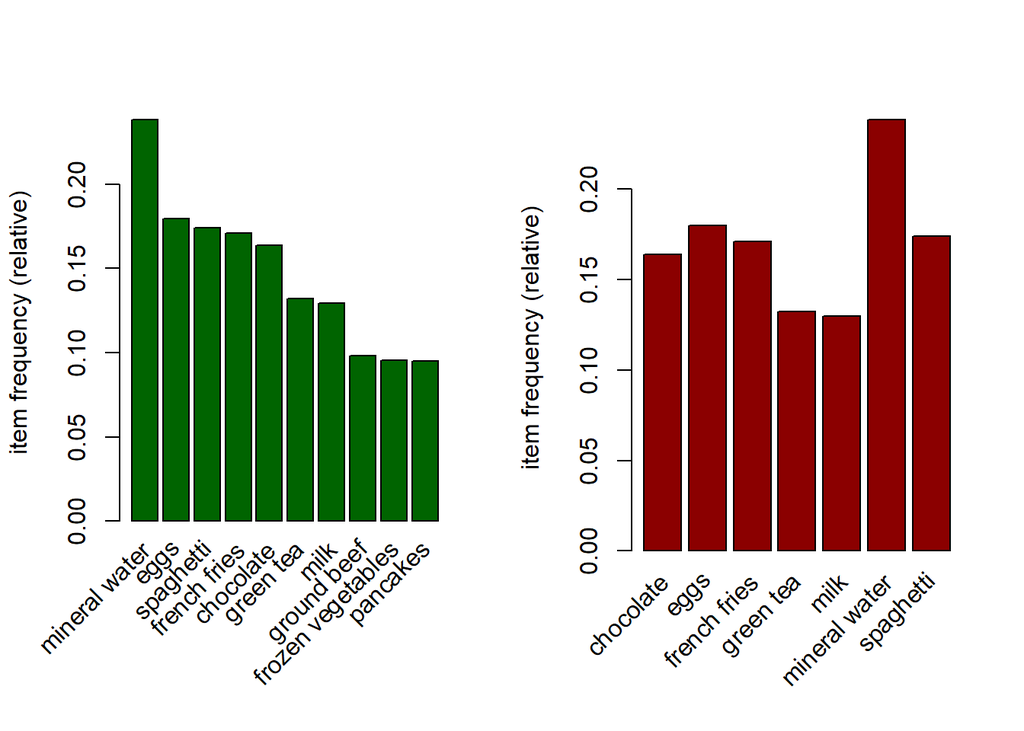

```r
par(mfrow = c(1, 2))

# plot the frequency of items
itemFrequencyPlot(Transactions, topN = 10,col="darkgreen")
itemFrequencyPlot(Transactions, support = 0.1,col="darkred")
```

### Building the Model

#model1 : support =0.001 and confidence = 0.8

```r
sales.rules <- apriori (Transactions, parameter = list(supp = 0.001, conf = 0.8))
```

```
## Apriori
##
## Parameter specification:
##  confidence minval smax arem  aval originalSupport maxtime support minlen
##         0.8    0.1    1 none FALSE            TRUE       5   0.001      1
##  maxlen target  ext
##      10  rules TRUE
##
## Algorithmic control:
##  filter tree heap memopt load sort verbose
##     0.1 TRUE TRUE  FALSE TRUE    2    TRUE
##
## Absolute minimum support count: 7
##
## set item appearances ...[0 item(s)] done [0.00s].
## set transactions ...[119 item(s), 7501 transaction(s)] done [0.00s].
## sorting and recoding items ... [116 item(s)] done [0.00s].
## creating transaction tree ... done [0.00s].
## checking subsets of size 1 2 3 4 5 6 done [0.01s].
## writing ... [74 rule(s)] done [0.00s].
## creating S4 object  ... done [0.00s].
```

```r
sales.rules
```

```
## set of 74 rules
```

We build Model1 using association rules and apriori() function, min support=0.001, confidence=0.8 Observation: Model 1 has 74 rules.

### increasing the support and lowering the confidence level

```r
# Building a apriori model with Min Support as 0.002 and confidence as 0.8.
sales.rules2<- apriori (Transactions,parameter = list(supp = 0.002, conf = 0.8))
```

```
## Apriori
##
## Parameter specification:
##  confidence minval smax arem  aval originalSupport maxtime support minlen
##         0.8    0.1    1 none FALSE            TRUE       5   0.002      1
##  maxlen target  ext
##      10  rules TRUE
##
## Algorithmic control:
##  filter tree heap memopt load sort verbose
##     0.1 TRUE TRUE  FALSE TRUE    2    TRUE
##
## Absolute minimum support count: 15
##
## set item appearances ...[0 item(s)] done [0.00s].
## set transactions ...[119 item(s), 7501 transaction(s)] done [0.00s].
## sorting and recoding items ... [115 item(s)] done [0.00s].
## creating transaction tree ... done [0.00s].
## checking subsets of size 1 2 3 4 5 done [0.00s].
## writing ... [2 rule(s)] done [0.00s].
## creating S4 object  ... done [0.00s].
```

```r
# Building a apriori model with Min Support as 0.002 and confidence as 0.6.
sales.rules2<- apriori (Transactions,parameter = list(supp = 0.002, conf = 0.6))
```

```
## Apriori
##
## Parameter specification:
##  confidence minval smax arem  aval originalSupport maxtime support minlen
##         0.6    0.1    1 none FALSE            TRUE       5   0.002      1
##  maxlen target  ext
##      10  rules TRUE
##
## Algorithmic control:
##  filter tree heap memopt load sort verbose
##     0.1 TRUE TRUE  FALSE TRUE    2    TRUE
##
## Absolute minimum support count: 15
##
## set item appearances ...[0 item(s)] done [0.00s].
## set transactions ...[119 item(s), 7501 transaction(s)] done [0.00s].
## sorting and recoding items ... [115 item(s)] done [0.00s].
## creating transaction tree ... done [0.00s].
## checking subsets of size 1 2 3 4 5 done [0.00s].
## writing ... [43 rule(s)] done [0.00s].
## creating S4 object  ... done [0.00s].
```

Exploring our model

```r
summary(sales.rules)
```

```
## set of 74 rules
##
## rule length distribution (lhs + rhs):sizes
##  3  4  5  6
## 15 42 16  1
##
##    Min. 1st Qu.  Median    Mean 3rd Qu.    Max.
##   3.000   4.000   4.000   4.041   4.000   6.000
##
## summary of quality measures:
##     support           confidence        coverage             lift
##  Min.   :0.001067   Min.   :0.8000   Min.   :0.001067   Min.   : 3.356
##  1st Qu.:0.001067   1st Qu.:0.8000   1st Qu.:0.001333   1st Qu.: 3.432
##  Median :0.001133   Median :0.8333   Median :0.001333   Median : 3.795
##  Mean   :0.001256   Mean   :0.8504   Mean   :0.001479   Mean   : 4.823
##  3rd Qu.:0.001333   3rd Qu.:0.8889   3rd Qu.:0.001600   3rd Qu.: 4.877
##  Max.   :0.002533   Max.   :1.0000   Max.   :0.002666   Max.   :12.722
##      count
##  Min.   : 8.000
##  1st Qu.: 8.000
##  Median : 8.500
##  Mean   : 9.419
##  3rd Qu.:10.000
##  Max.   :19.000
##
## mining info:
##          data ntransactions support confidence
##  Transactions          7501   0.001        0.8
```

##Observing rules built in our model

```r
inspect(sales.rules[1:5])
```

```
##     lhs                             rhs             support     confidence
## [1] {frozen smoothie,spinach}    => {mineral water} 0.001066524 0.8888889
## [2] {bacon,pancakes}             => {spaghetti}     0.001733102 0.8125000
## [3] {nonfat milk,turkey}         => {mineral water} 0.001199840 0.8181818
## [4] {ground beef,nonfat milk}    => {mineral water} 0.001599787 0.8571429
## [5] {mushroom cream sauce,pasta} => {escalope}      0.002532996 0.9500000
##     coverage    lift      count
## [1] 0.001199840  3.729058  8
## [2] 0.002133049  4.666587 13
## [3] 0.001466471  3.432428  9
## [4] 0.001866418  3.595877 12
## [5] 0.002666311 11.976387 19
```

Observation:

If a customer buys frozen smoothie and spinach, they are 88% likely to buy mineral water also

If a customer buys bacon and pancake, they are 81% likely to buy spaghetti also.

If a customer buys mushroom cream sauce, and pasta, they are 95% likely to buy escalope also

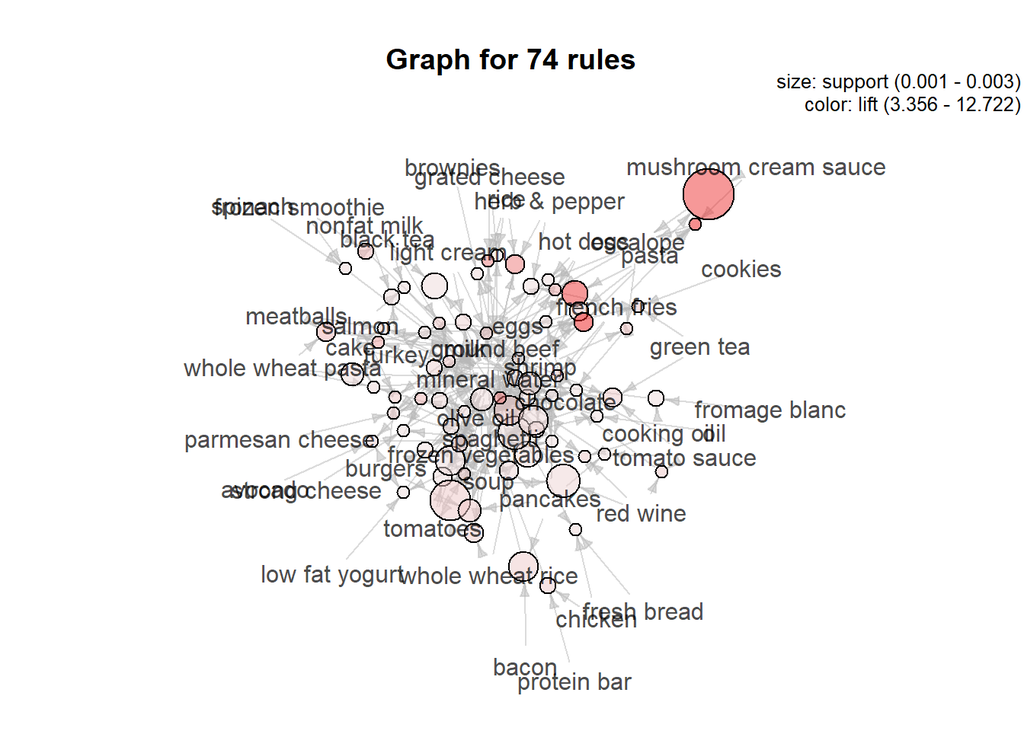

```r
library(arulesViz)
plot(sales.rules,method = "graph",)
```